# Assignment 17

Hughes, O’Connell, Wang

Sections A,C: Wednesday, November 6, 2019 Section B: Tuesday, November 12, 2019

## Activity: Developing a good prediction model using CV

What variables are good predictors of how well you can guess your instructor’s age?

This activity is designed to have you bring together various aspects of model building along with cross-validation techniques to come up with a good prediction model for the above using avilable data. We will use the in-class survey data that you completed on last lecture using Google Forms. The data is in the file `STA363_survey.csv`.

### Data Processing

The code below reads in the survey data, and performs some essential data processing. The `names()` function is used to display how the variable names were recorded in Google Forms … they’re descriptive, but way too long for the purpose of coding. So, we will shorten them below.

```r
survey <- read.csv("STA363_survey.csv", stringsAsFactors = FALSE)
names(survey)
```

```
##  [1] "Timestamp"
##  [2] "In.what.section.of.the.course.are.you.enrolled."
##  [3] "What.is.your.class.standing."
##  [4] "In.which.division.is.your.primary.major.housed."
##  [5] "Provide.a.random.number.between.0.and.30."
##  [6] "On.average..how.many.minutes.do.you.exercise.and.or.play.a.sport.per.week...Please.enter.a.single.number."
##  [7] "Do.your.political.tendencies..mostly..match.that.of.your.parents."
##  [8] "Do.you.identify.as.male."
##  [9] "Are.you.an.international.student."
## [10] "How.many.celebrities.do.you.follow.on.social.media..Facebook..Twitter..Instagram..etc........Please.enter.a.single.number.."
## [11] "Do.you.smoke."
## [12] "What.is.your.approximate.height..in.inches.."
## [13] "How.many.siblings.do.you.have."
## [14] "At.the.time.of.your.birth..what.was.your.father.s.age."
## [15] "At.the.time.of.your.birth..what.was.your.mother.s.age."
## [16] "In.your.approximation..what.is.the.age.of.your.instructor...Answer.about.the.primary.instructor.of.your.course..Section.A..Hughes..Section.B..O.Connell..Section.C..Wang.."
## [17] "What.is.your.favorite.time.of.day."
## [18] "Provide.a.random.number.between.0.and.30..1"
```

```r
names(survey) <- c("Timestamp", "Section", "Class", "Division", "Random1", "ExerMinutes",
                   "Political", "Male", "International", "NCelebs", "Smoke", "Height",
                   "NSiblings", "DadAge", "MomAge", "InstAge", "FavoTime", "Random2")
```

We will also do some data cleaning here, removing the timestamp (which we don’t need) and computing the errors for the age guesses (our response variable for today’s assignment).

```r
survey <- survey %>%
    select(-Timestamp) %>%
    mutate(age.error = case_when(Section == "Section A - MW 1:15pm-2:35pm (Mr. Hughes)"~ InstAge - 56,
                                 Section == "Section B - TR 4:25pm-5:45pm (Dr. O'Connell)"~InstAge -28,
                                 Section == "Section C - MW 1:15pm-2:35pm (Dr. Wang)"~InstAge -30,))
```

We also want to set blank entries to be missing.

```r
survey$Smoke[which(survey$Smoke=="")] <- NA
```

## A random tangent (pun intended)

#### ASIDE: Can people really be random?

On the survey, you were asked *twice* to provide a random number between 0 and 30. Let’s see if you could really be truly random!

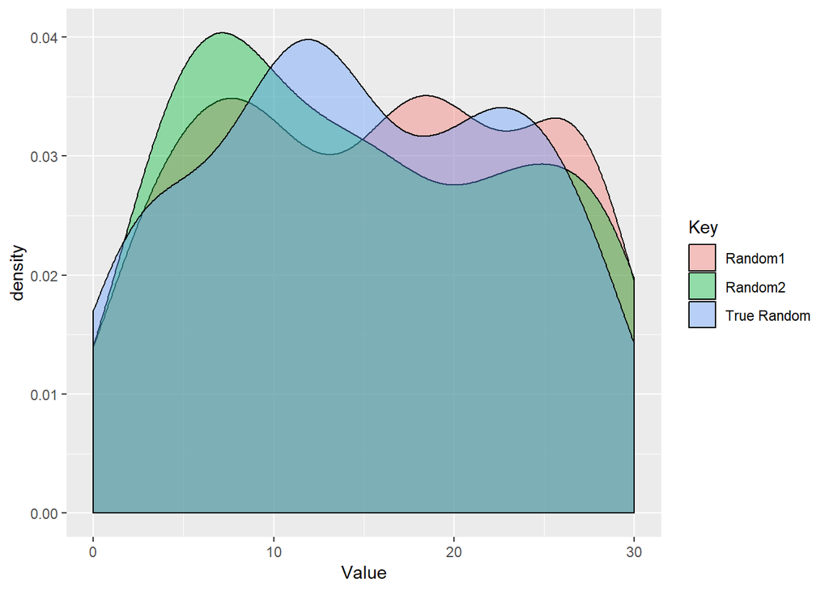

```r
nsurvey = nrow(survey)
xxx <- runif(nsurvey, 0, 30)  # 126 randomly generated uniform numbers between 0 and 30
yyy <- runif(nsurvey, 0, 30)  # 126 randomly generated uniform numbers between 0 and 30, will use later
ddd <- data.frame(Key=rep("True Random", nsurvey),
                  Value = xxx)
survey.tall <- survey %>%
  select(Random1, Random2) %>%
  gather(key=Key, value=Value) %>%
  mutate(Source = "Survey")

ggplot(bind_rows(survey.tall, ddd) ) +
  geom_density(aes(x=Value, fill=Key), alpha=0.4)
```

*This graph doesnt tell us much*

Below, we look at the pattern of your “random” choices on the survey vs what actual randomness looks like. Do you think your “random” guesses qualify?

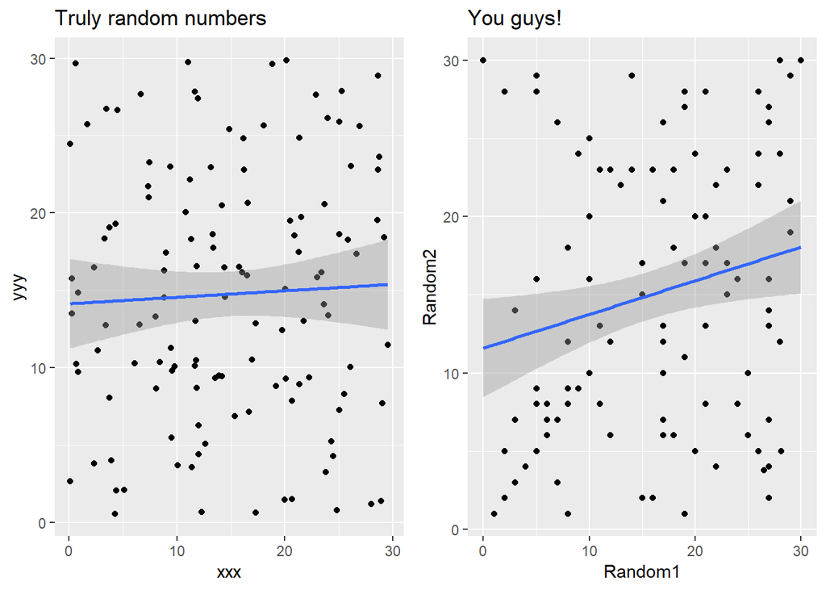

```r
ddd <- data.frame(xxx, yyy)
p1 <- ggplot(ddd, aes(x=xxx, y=yyy)) +
  geom_point() + geom_smooth(method="lm") + ggtitle("Truly random numbers")

p2 <- ggplot(survey, aes(x=Random1, y=Random2)) +
  geom_point() + geom_smooth(method="lm") + ggtitle("You guys!")

grid.arrange(p1,p2,nrow=1)  # plot comparing association between your guesses vs true randomness
```

Can we predict your second “random” number guess from your FIRST random number guess?

```r
summary(lm(Random2 ~ Random1, data=survey))
```

```
##
## Call:
## lm(formula = Random2 ~ Random1, data = survey)
##
## Residuals:
##     Min      1Q  Median      3Q     Max
## -15.405  -6.683  -1.358   7.593  18.413
##
## Coefficients:
##             Estimate Std. Error t value Pr(>|t|)
## (Intercept) 11.58655    1.58419   7.314 2.82e-11 ***
## Random1      0.21549    0.08905   2.420    0.017 *
## ---
## Signif. codes:  0 '***' 0.001 '**' 0.01 '*' 0.05 '.' 0.1 ' ' 1
##
## Residual standard error: 8.662 on 124 degrees of freedom
## Multiple R-squared:  0.0451, Adjusted R-squared:  0.0374
## F-statistic: 5.856 on 1 and 124 DF,  p-value: 0.01697
```

*Grpah You guys! tells us that we hace some type of systematic guessing compared to Truly random numbers*

## BACK TO THE PROBLEM: Some preliminary EDA

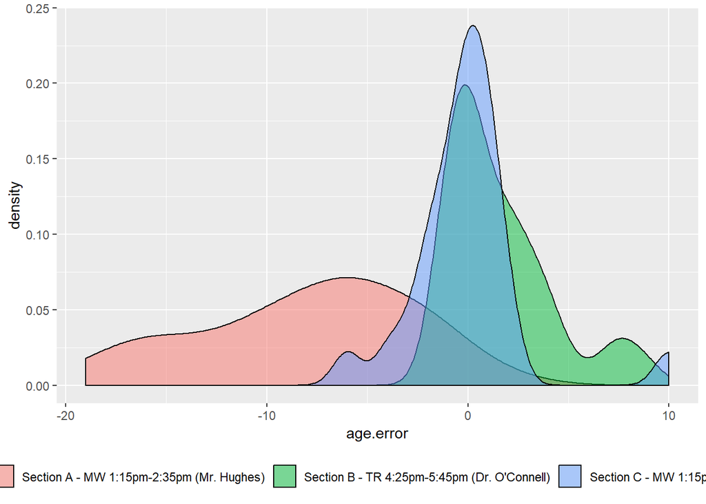

```r
ggplot(survey) +
   geom_density(aes(x=age.error, fill=Section), alpha=0.5) +
   theme(legend.position="bottom")
```

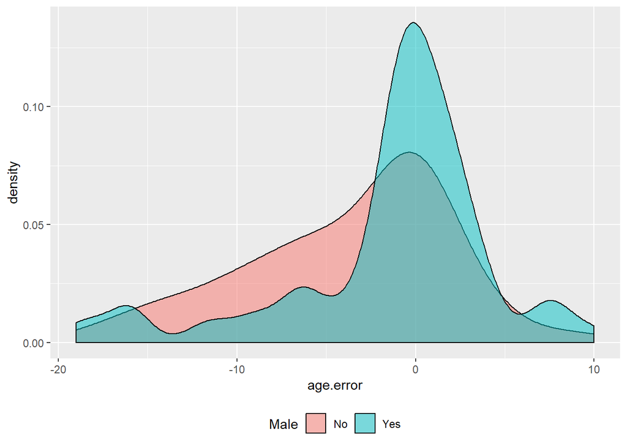

```r
ggplot(survey) +
   geom_density(aes(x=age.error, fill=Male), alpha=0.5) +
   theme(legend.position="bottom")
```

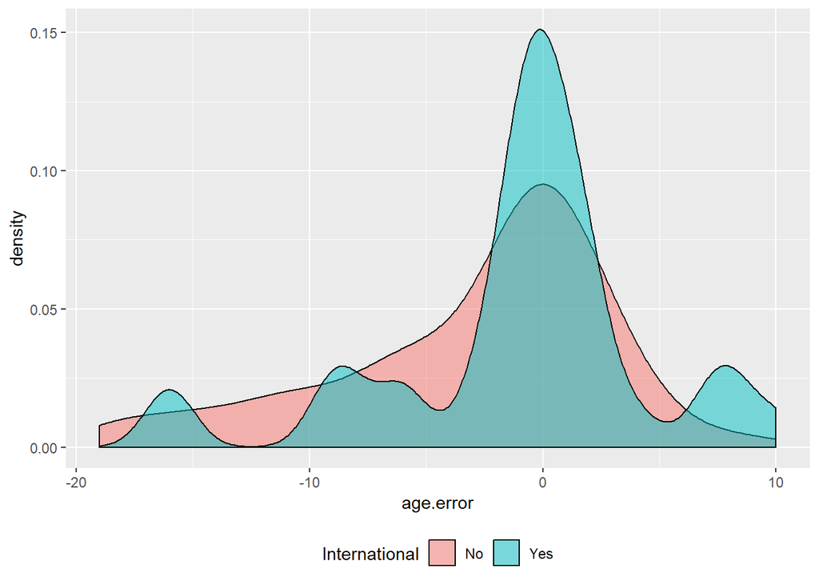

```r
ggplot(survey) +
   geom_density(aes(x=age.error, fill=International), alpha=0.5) +
   theme(legend.position="bottom")
```

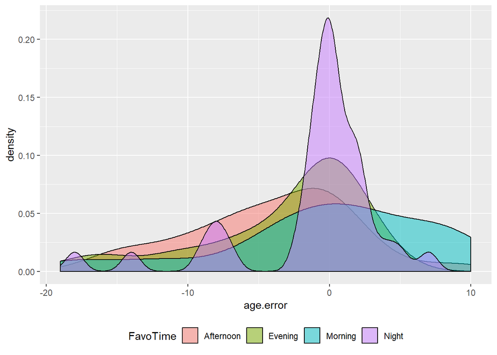

```r
ggplot(survey) +
   geom_density(aes(x=age.error, fill=FavoTime), alpha=0.5) +
   theme(legend.position="bottom")
```

A scatterplot matrix of some of the numerical variables:

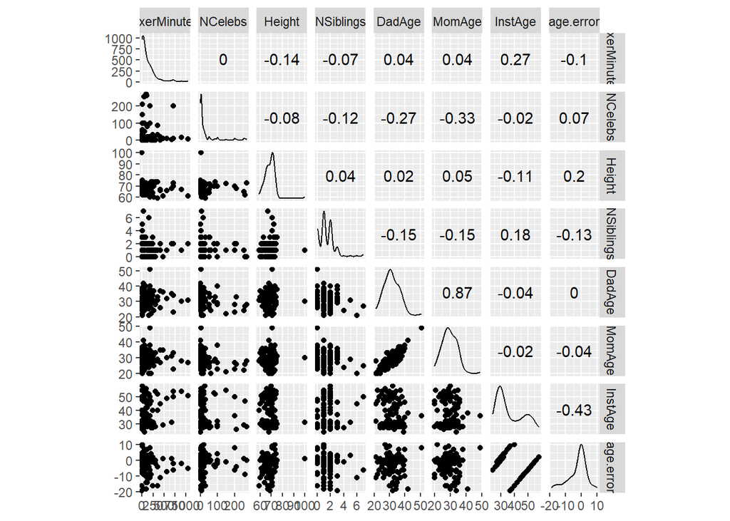

```r
ggscatmat(survey, columns = c(5,9,11,12,13,14,15,18))
```

### YOUR ACTIVITY

Your goal is simple: **develop the best statistical model that you can for predicting the error in your guess of your instructor’s age.**

```r
survey$Height[which(survey$Height=="")] <- NA
survey$Height[which(survey$Height=="100")] <- NA

survey <- survey %>%
  drop_na()

model1 <- lm(age.error ~ Section + Class + Division + Random1 + ExerMinutes + Political +  Male +  International + NCelebs + Smoke + Height + NSiblings + DadAge + MomAge +FavoTime + Random2, data=survey)
null.fit <- lm(age.error ~ 1, data=survey)
step.pick.forward <- step(null.fit, scope=formula(model1), direction="forward")
```

```
## Start:  AIC=406.86
## age.error ~ 1
##
##                 Df Sum of Sq    RSS    AIC
## + Section        2   2216.84 1757.4 317.84
## + Class          3    380.31 3593.9 401.39
## + Height         1    164.29 3810.0 404.05
## + Male           1    100.08 3874.2 405.95
## + Random1        1     95.59 3878.7 406.08
## <none>                       3974.3 406.86
## + FavoTime       3    185.00 3789.3 407.42
## + NSiblings      1     49.02 3925.2 407.44
## + ExerMinutes    1     41.43 3932.8 407.66
## + International  1     25.54 3948.7 408.12
## + Political      1     10.96 3963.3 408.54
## + Smoke          1      9.97 3964.3 408.57
## + MomAge         1      7.46 3966.8 408.64
## + Random2        1      2.30 3972.0 408.79
## + DadAge         1      0.01 3974.2 408.86
## + NCelebs        1      0.00 3974.3 408.86
## + Division       3     55.54 3918.7 411.25
##
## Step:  AIC=317.84
## age.error ~ Section
##
##                 Df Sum of Sq    RSS    AIC
## + Smoke          1   112.449 1645.0 312.30
## + Random1        1    43.630 1713.8 316.97
## + Height         1    34.823 1722.6 317.55
## + Political      1    31.612 1725.8 317.77
## <none>                       1757.4 317.84
## + ExerMinutes    1    28.048 1729.4 318.00
## + MomAge         1    10.515 1746.9 319.15
## + Random2        1     2.901 1754.5 319.65
## + DadAge         1     1.779 1755.6 319.72
## + NCelebs        1     1.093 1756.3 319.76
## + NSiblings      1     0.496 1756.9 319.80
## + Male           1     0.343 1757.1 319.81
## + International  1     0.142 1757.3 319.83
## + Class          3    56.796 1700.6 320.09
```

[output cut: 44 more lines]

```
##
##                 Df Sum of Sq    RSS    AIC
## <none>                       1574.0 311.27
## + Height         1    20.578 1553.5 311.77
## + Political      1    19.253 1554.8 311.87
## + MomAge         1     9.262 1564.8 312.60
## + NSiblings      1     8.153 1565.9 312.68
## + Male           1     5.153 1568.9 312.90
## + NCelebs        1     0.756 1573.3 313.22
## + Random2        1     0.732 1573.3 313.22
## + DadAge         1     0.245 1573.8 313.25
## + International  1     0.029 1574.0 313.27
## + Class          3    35.811 1538.2 314.65
## + FavoTime       3    27.658 1546.4 315.25
## + Division       3    15.861 1558.2 316.12
```

```r
summary(step.pick.forward)
```

```
##
## Call:
## lm(formula = age.error ~ Section + Smoke + ExerMinutes + Random1,
##     data = survey)
##
## Residuals:
##      Min       1Q   Median       3Q      Max
## -10.7325  -1.7477  -0.0363   2.1153  11.2035
##
## Coefficients:
##                                                      Estimate Std. Error
## (Intercept)                                         -8.167603   1.012725
## SectionSection B - TR 4:25pm-5:45pm (Dr. O'Connell)  9.948567   0.830118
## SectionSection C - MW 1:15pm-2:35pm (Dr. Wang)       8.443004   1.022452
## SmokeYes                                             3.024133   1.077096
## ExerMinutes                                          0.003047   0.001962
## Random1                                             -0.062011   0.041827
##                                                     t value Pr(>|t|)
## (Intercept)                                          -8.065 1.08e-12 ***
## SectionSection B - TR 4:25pm-5:45pm (Dr. O'Connell)  11.985  < 2e-16 ***
## SectionSection C - MW 1:15pm-2:35pm (Dr. Wang)        8.258 4.04e-13 ***
## SmokeYes                                              2.808  0.00592 **
## ExerMinutes                                           1.552  0.12349
## Random1                                              -1.483  0.14110
## ---
## Signif. codes:  0 '***' 0.001 '**' 0.01 '*' 0.05 '.' 0.1 ' ' 1
##
## Residual standard error: 3.818 on 108 degrees of freedom
## Multiple R-squared:  0.6039, Adjusted R-squared:  0.5856
## F-statistic: 32.94 on 5 and 108 DF,  p-value: < 2.2e-16
```

```r
train_control <- trainControl(method="cv", number=5)
model <- train(age.error ~ Section + Smoke + ExerMinutes + Random1, data=survey, trControl=train_control, method="lm")
print(model)
```

```
## Linear Regression
##
## 114 samples
##   4 predictor
##
## No pre-processing
## Resampling: Cross-Validated (5 fold)
## Summary of sample sizes: 90, 92, 91, 91, 92
## Resampling results:
##
##   RMSE      Rsquared   MAE
##   3.897359  0.5993881  2.913604
##
## Tuning parameter 'intercept' was held constant at a value of TRUE
```

The following rules apply:

- You may use any of the variables from the survey as potential predictors of the error of the guess **except** the *actual* guess of your instructor’s age. You may also create any new variable you wish from information on the survey to use as a predictor (e.g. transformations or dummy variables). You may also transform the response.
- You may use any or all variable selection methods at your disposal (forward stepwise, backward stepwise, best-subsets) to help guide you through model choices.
- **You must use 5-fold cross-validation as the method of testing any models you consider, and RMSE must be the criterion you use for comparing models.** *(We set the seed value for random partitioning into training and test data sets, so no one will have an advantage based on differences in random partitioning!)*
- At the end of the Markdown document, you must:
  - indicate what survey items are important predictors
  - cite the RMSE (and provide supporting output) for your chosen model.

**WINNER WINNER CHICKEN DINNER.** The person who achieves the best RMSE value will receive a 5-point bonus towards their homework grade!

Parts Section + Smoke + ExerMinutes + Random1 are most important.

My RMSE for my chosen model was 3.897359